# Machine Learning Project

Jorge de la Vega

21/12/2014

## Introduction

This document describes the analysis made to find a prediction model for the data on the way exercise is due using accelerometers. This data focus on how well they do the exercise. The goal will be to use data from accelerometers on the belt, forearm, arm, and dumbell of 6 participants. They were asked to perform barbell lifts correctly and incorrectly in 5 different ways.

## Summary and Conclusions

After making some adjustment to the dataset to get tidy data and reducing the set of variables from 159 to 50, I considered different algorithms for prediction, namely trees, random forests and boosting. Regression was not considered since does not seem to be a good approach for a response variable that is categorical.

## Methodology

The variables that were removed from the dataset were those variables that had NA’s, mostly variables that are statistics (totals, means, variances, standard deviations, kurtosis and so on) from the original data. I decided to keep the participant as factor variable, since the results might be affected by proper characteristics of the subject.

```r
#Reading, cleaning and setting up
library(plyr)
library(caret)
library(rattle)
training <- read.csv("pml-training.csv")
testing <- read.csv("pml-testing.csv")

#set of vars to keep
vars <- c(2,8:10,37:48,60:68,84:86,113:124,151:159)
training <- training[,c(vars,160)]
testing <-testing[,vars]
```

The approach I am taking is to use 60% of the dataset training to build the model and 40% to compute the out of sample errors. The tesing dataset is use to get the final prediction to submit in the second part of the project.

### Trees

The first approach is to use the tree partition approach. In this case the accuracy of the model is low, 51%.

```r
inTrain <- createDataPartition(y = training$classe, p = 0.6, list=F)
system.time(m1 <- train(classe ~ ., data = training[inTrain,], method = "rpart"))
```

```
##    user  system elapsed
##  47.716   0.073  47.757
```

```r
m1
```

```
## CART
##
## 11776 samples
##    49 predictors
##     5 classes: 'A', 'B', 'C', 'D', 'E'
##
## No pre-processing
## Resampling: Bootstrapped (25 reps)
##
## Summary of sample sizes: 11776, 11776, 11776, 11776, 11776, 11776, ...
##
## Resampling results across tuning parameters:
##
##   cp          Accuracy   Kappa       Accuracy SD  Kappa SD
##   0.03547698  0.5110398  0.36231703  0.01912853   0.02859825
##   0.06158045  0.4135942  0.20359778  0.06324980   0.10580468
##   0.11699098  0.3274280  0.06453081  0.04075134   0.06338992
##
## Accuracy was used to select the optimal model using  the largest value.
## The final value used for the model was cp = 0.03547698.
```

```r
print(m1$finalModel)
```

```
## n= 11776
##
## node), split, n, loss, yval, (yprob)
##       * denotes terminal node
##
##  1) root 11776 8428 A (0.28 0.19 0.17 0.16 0.18)
##    2) roll_belt< 129.5 10708 7401 A (0.31 0.21 0.19 0.18 0.11)
##      4) pitch_forearm< -33.95 935    5 A (0.99 0.0053 0 0 0) *
##      5) pitch_forearm>=-33.95 9773 7396 A (0.24 0.23 0.21 0.2 0.12)
##       10) magnet_dumbbell_y< 436.5 8268 5932 A (0.28 0.18 0.24 0.19 0.11)
##         20) roll_forearm< 122.5 5107 3009 A (0.41 0.18 0.18 0.17 0.059) *
##         21) roll_forearm>=122.5 3161 2104 C (0.075 0.18 0.33 0.23 0.18) *
##       11) magnet_dumbbell_y>=436.5 1505  726 B (0.027 0.52 0.046 0.23 0.17) *
##    3) roll_belt>=129.5 1068   41 E (0.038 0 0 0 0.96) *
```

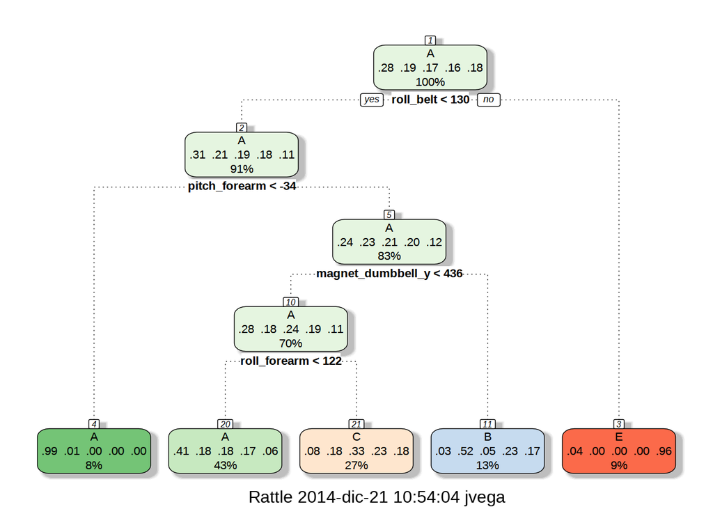

```r
fancyRpartPlot(m1$finalModel) #print the classification tree
```

The out of sample error is computed using the rest of the training set, getting an estimate of out of sample error of 1- accuracy which is approximately 50%.

```r
pred1 <- predict(m1,newdata= training[-inTrain,])
confusionMatrix(pred1,training[-inTrain,]$classe)
```

```
## Confusion Matrix and Statistics
##
##           Reference
## Prediction    A    B    C    D    E
##          A 1976  623  657  573  188
##          B   54  523   40  227  211
##          C  169  372  671  486  371
##          D    0    0    0    0    0
##          E   33    0    0    0  672
##
## Overall Statistics
##
##                Accuracy : 0.4897
##                  95% CI : (0.4786, 0.5008)
##     No Information Rate : 0.2845
##     P-Value [Acc > NIR] : < 2.2e-16
##
##                   Kappa : 0.3336
##  Mcnemar's Test P-Value : NA
##
## Statistics by Class:
##
##                      Class: A Class: B Class: C Class: D Class: E
## Sensitivity            0.8853  0.34453  0.49050   0.0000  0.46602
## Specificity            0.6364  0.91593  0.78419   1.0000  0.99485
## Pos Pred Value         0.4919  0.49573  0.32431      NaN  0.95319
## Neg Pred Value         0.9331  0.85348  0.87935   0.8361  0.89217
## Prevalence             0.2845  0.19347  0.17436   0.1639  0.18379
## Detection Rate         0.2518  0.06666  0.08552   0.0000  0.08565
## Detection Prevalence   0.5120  0.13446  0.26370   0.0000  0.08985
## Balanced Accuracy      0.7609  0.63023  0.63734   0.5000  0.73043
```

### Random forests

```r
control1 <- trainControl(method = "cv", number = 4)
system.time(m2 <- train(classe ~ ., data = training[inTrain,], method = "rf", trControl = control1, prox = F))
```

```
##    user  system elapsed
## 389.124   0.564 389.414
```

```r
m2
```

```
## Random Forest
##
## 11776 samples
##    49 predictors
##     5 classes: 'A', 'B', 'C', 'D', 'E'
##
## No pre-processing
## Resampling: Cross-Validated (4 fold)
##
## Summary of sample sizes: 8831, 8832, 8832, 8833
##
## Resampling results across tuning parameters:
##
##   mtry  Accuracy   Kappa      Accuracy SD   Kappa SD
##    2    0.9882813  0.9851747  0.0007052907  0.0008915161
##   27    0.9875174  0.9842080  0.0023564406  0.0029837933
##   53    0.9806391  0.9755052  0.0044075821  0.0055812951
##
## Accuracy was used to select the optimal model using  the largest value.
## The final value used for the model was mtry = 2.
```

```r
print(m2$finalModel)
```

```
##
## Call:
##  randomForest(x = x, y = y, mtry = param$mtry, proximity = ..1)
##                Type of random forest: classification
##                      Number of trees: 500
## No. of variables tried at each split: 2
##
##         OOB estimate of  error rate: 0.9%
## Confusion matrix:
##      A    B    C    D    E class.error
## A 3344    2    0    0    2 0.001194743
## B   17 2256    6    0    0 0.010092146
## C    0   17 2033    4    0 0.010223953
## D    0    0   46 1881    3 0.025388601
## E    0    0    0    9 2156 0.004157044
```

```r
#predict values
pred2 <- predict(m2, newdata = training[-inTrain,])
confusionMatrix(pred2,training[-inTrain,]$classe)
```

```
## Confusion Matrix and Statistics
##
##           Reference
## Prediction    A    B    C    D    E
##          A 2232    7    0    0    0
##          B    0 1510   11    0    0
##          C    0    1 1355   24    2
##          D    0    0    2 1257    4
##          E    0    0    0    5 1436
##
## Overall Statistics
##
##                Accuracy : 0.9929
##                  95% CI : (0.9907, 0.9946)
##     No Information Rate : 0.2845
##     P-Value [Acc > NIR] : < 2.2e-16
##
##                   Kappa : 0.991
##  Mcnemar's Test P-Value : NA
##
## Statistics by Class:
##
##                      Class: A Class: B Class: C Class: D Class: E
## Sensitivity            1.0000   0.9947   0.9905   0.9774   0.9958
## Specificity            0.9988   0.9983   0.9958   0.9991   0.9992
## Pos Pred Value         0.9969   0.9928   0.9805   0.9952   0.9965
## Neg Pred Value         1.0000   0.9987   0.9980   0.9956   0.9991
## Prevalence             0.2845   0.1935   0.1744   0.1639   0.1838
## Detection Rate         0.2845   0.1925   0.1727   0.1602   0.1830
## Detection Prevalence   0.2854   0.1939   0.1761   0.1610   0.1837
## Balanced Accuracy      0.9994   0.9965   0.9932   0.9883   0.9975
```

### Boosting

```r
control1 <- trainControl(method = "cv", number = 4)
system.time(m3 <- train(classe ~ ., data = training[inTrain,], method = "gbm", trControl = control1, verbose = F))
```

```
##    user  system elapsed
## 191.461   0.212 191.536
```

```r
m3
```

```
## Stochastic Gradient Boosting
##
## 11776 samples
##    49 predictors
##     5 classes: 'A', 'B', 'C', 'D', 'E'
##
## No pre-processing
## Resampling: Cross-Validated (4 fold)
##
## Summary of sample sizes: 8830, 8832, 8834, 8832
##
## Resampling results across tuning parameters:
##
##   interaction.depth  n.trees  Accuracy   Kappa      Accuracy SD
##   1                   50      0.7499120  0.6828694  0.007987500
##   1                  100      0.8167439  0.7682011  0.005825645
##   1                  150      0.8479095  0.8076372  0.004539358
##   2                   50      0.8527502  0.8134468  0.005319556
##   2                  100      0.9032770  0.8776162  0.002224451
##   2                  150      0.9300269  0.9114826  0.001915212
##   3                   50      0.8932553  0.8648629  0.007429597
##   3                  100      0.9362249  0.9193033  0.004838155
##   3                  150      0.9556733  0.9439204  0.003545677
##   Kappa SD
##   0.009908635
##   0.007278959
##   0.005679831
##   0.006808579
##   0.002785939
##   0.002422397
##   0.009359542
##   0.006085214
##   0.004467214
##
## Tuning parameter 'shrinkage' was held constant at a value of 0.1
## Accuracy was used to select the optimal model using  the largest value.
## The final values used for the model were n.trees = 150,
##  interaction.depth = 3 and shrinkage = 0.1.
```

```r
print(m3$finalModel)
```

```
## A gradient boosted model with multinomial loss function.
## 150 iterations were performed.
## There were 53 predictors of which 39 had non-zero influence.
```

```r
#predict values for out of sample error
pred3 <- predict(m3, newdata = training[-inTrain,])
confusionMatrix(pred2,training[-inTrain,]$classe)
```

[output not shown]

```
## Confusion Matrix and Statistics
##
##           Reference
## Prediction    A    B    C    D    E
##          A 2232    7    0    0    0
##          B    0 1510   11    0    0
##          C    0    1 1355   24    2
##          D    0    0    2 1257    4
##          E    0    0    0    5 1436
##
## Overall Statistics
##
##                Accuracy : 0.9929
##                  95% CI : (0.9907, 0.9946)
##     No Information Rate : 0.2845
##     P-Value [Acc > NIR] : < 2.2e-16
##
##                   Kappa : 0.991
##  Mcnemar's Test P-Value : NA
##
## Statistics by Class:
##
##                      Class: A Class: B Class: C Class: D Class: E
## Sensitivity            1.0000   0.9947   0.9905   0.9774   0.9958
## Specificity            0.9988   0.9983   0.9958   0.9991   0.9992
## Pos Pred Value         0.9969   0.9928   0.9805   0.9952   0.9965
## Neg Pred Value         1.0000   0.9987   0.9980   0.9956   0.9991
## Prevalence             0.2845   0.1935   0.1744   0.1639   0.1838
## Detection Rate         0.2845   0.1925   0.1727   0.1602   0.1830
## Detection Prevalence   0.2854   0.1939   0.1761   0.1610   0.1837
## Balanced Accuracy      0.9994   0.9965   0.9932   0.9883   0.9975
```